# User guide – microxanox R Package for microbial oxic and anoxic ecosystem simulations

Owen Petchey, Rainer M Krug

20 July, 2021

```r
library(microxanox)
```

# Introduction

The aims of the `microxanox` package are:

- Facilitate reproduction of the results of [Bush et al 2017](https://www.nature.com/articles/s41467-017-00912-x).
- Include new functionality that allows new research questions to be answered.

We added functionality for:

- Adding random noise in substrate concentrations.
- Adding temporally varying oxygen diffusivity.
- Including immigration.
- Setting minimum population abundances.
- Multiple strains per functional group.

We also include a function for visualising results, though *please note that it is provided for convenience, and not for production of perfectly formatted print-ready graphs.*

Here (again) is the original publication: https://www.nature.com/articles/s41467-017-00912-x

And here is the Supplementary Information, including the table of parameter values: https://static-content.springer.com/esm/art%3A10.1038%2Fs41467-017-00912-x/MediaObjects/41467_2017_912_MOESM1_ESM.pdf

## Notation

Note that in this package we use the notation from the Table S1 of the Bush et al 2017 Supplementary information, and not the notation in the main text of Bush et al 2017. (There is only one small difference between these: In the main text the notation is simplified to `y_S_PB` ($y_{S,PB}$) (which is `y_SR_PB` ($y_{SR,PB}$) in Table S1) and `y_S_SB` ($y_{S,SB}$) (which is y_SO_SB ($y_{SO,SB}$) in Table S1). We also use `Pr_cB` ($Pr_B$) instead of `P_CB` ($P_{CB}$).

## Model dimensions

- Time: hours
- Volume: litres
- Substrate quantity: micromoles
- Organism quantity: cells

# Modelling framework

The framework used for running a simulation, and for varying aspects of a simulation run is:

- Define the default simulation conditions (i.e. parameters and initial conditions).
- Use these defaults unless other conditions are specified.
- The function call `run_simulation()` would therefore run a simulation with default conditions.
- The function call `run_simulation(initial_state = init_state_favouring_anoxic)` would run the simulation with the specified initial state values, and otherwise all the specified defaults.

# Conditions that must be defined

Conditions that must be set, with an example of setting them:

## The dynamic model

The ordinary differential equations for the rates of change are specified in the function `bushplus_dynamic_model()`. This augmented version of the model published in Bush et al 2017 can handle multiple strains within each of the three functional groups, temporal variation in oxygen diffusivity, and events (see below for event definition).

```r
default_dynamic_model <- bushplus_dynamic_model
```

## The parameter and initial state values

The parameter values and initial state values are held in one object. The function `new_starter` can be used to create this object. In the follow, we specify one strain per functional group, all parameter values as defined in Bush et al 2017, and starting conditions as the anoxic favouring conditions in Bush et al 2017.

```r
bush_anoxicstart_1strain <- new_starter(n_CB = 1,
                                        values_CB = "bush",
                                        n_PB = 1,
                                        values_PB = "bush",
                                        n_SB = 1,
                                        values_SB = "bush",
                                        values_other = "bush",
                                        values_initial_state = "bush_anoxic_fig2ab")
```

Here are the parameter values of the CB strain, for example

```r
bush_anoxicstart_1strain$CB
```

```
##   strain_name g_max_CB k_CB_P h_SR_CB   y_P_CB Pr_CB m_CB i_CB
## 1        CB_1     0.05    0.2     300 1.67e+08 6e-09 0.02    0
```

And here are the initial state values:

```r
bush_anoxicstart_1strain$initial_state
```

```
##  CB_1  PB_1  SB_1    SO    SR     O     P
## 5e+01 1e+07 1e+07 3e+02 3e+02 1e+01 1e+01
## attr(,"class")
## [1] "initial_state" "numeric"
```

### Modifying initial states and parameter values

Note that the function `new_initial_state` can be used to get a couple of preset initial states:

```r
new_initial_state(values = "bush_oxic_fig2cd")
```

```
##  CB_1  PB_1  SB_1    SO    SR     O     P
## 1e+08 1e+02 1e+02 5e+02 5e+01 3e+02 4e+00
## attr(,"class")
## [1] "initial_state" "numeric"
```

And the function `new_CB_strain_parameter` (and SB and PB equivalents) can be used to get preset organism parameters. Currently there is only one preset, however: “bush”.

```r
new_CB_strain_parameter(values = "bush")
```

```
##   strain_name g_max_CB k_CB_P h_SR_CB   y_P_CB Pr_CB m_CB i_CB
## 1        CB_1     0.05    0.2     300 1.67e+08 6e-09 0.02    0
```

Here we make a new set of parameters, in which there are three strains of CB, and one of each of SB and PB.

```r
bush_anoxicstart_311strain <- bush_anoxicstart_1strain
bush_anoxicstart_311strain$CB <- new_CB_strain_parameter(n=3, values = "bush")
bush_anoxicstart_311strain
```

```
## $CB
##   strain_name g_max_CB k_CB_P h_SR_CB   y_P_CB Pr_CB m_CB i_CB
## 1        CB_1     0.05    0.2     300 1.67e+08 6e-09 0.02    0
## 2        CB_2     0.05    0.2     300 1.67e+08 6e-09 0.02    0
## 3        CB_3     0.05    0.2     300 1.67e+08 6e-09 0.02    0
##
## $PB
##   strain_name g_max_PB k_PB_SR k_PB_P h_O_PB  y_SR_PB   y_P_PB  m_PB i_PB
## 1        PB_1     0.07      10    0.5    100 12500000 1.67e+08 0.028    0
##
## $SB
##   strain_name g_max_SB k_SB_SO k_SB_P h_O_SB  y_SO_SB   y_P_SB m_SB i_SB
## 1        SB_1      0.1       5    0.5    100 33300000 1.67e+08 0.04    0
##
## $a_S
## [1] 0.001
##
## $a_O
## [1] 8e-04
##
## $a_P
## [1] 0.01
##
## $back_SR
## [1] 300
##
## $back_SO
## [1] 300
##
## $back_O
## [1] 300
##
## $back_P
## [1] 9.5
##
## $c
## [1] 4e-05
##
## $initial_state
##  CB_1  PB_1  SB_1    SO    SR     O     P
## 5e+01 1e+07 1e+07 3e+02 3e+02 1e+01 1e+01
## attr(,"class")
## [1] "initial_state" "numeric"
##
## attr(,"class")
## [1] "strain_parameter" "list"
```

## The duration of the simulation:

```r
default_sim_duration <- 2000
```

## The sampling interval:

```r
default_sim_sample_interval <- 1
```

## The oxygen diffusivity dynamics

Specified by giving a vector of values of $a_0$. These are then automatically spaced equally along the duration of the simulation. Here we specify no forcing of $a_0$.

```r
default_log10a_series <- c(log10(bush_anoxicstart_1strain$a_O),
                           log10(bush_anoxicstart_1strain$a_O))
```

Note that here we use the already set default value of $a_0$ and therefore must have already defined the default parameter values.

## Events

These are “things” that happen during the simulation. One has to specify what happens, and when it happens.

#### What happens

The event definition function currently available can add noise to a state variable, and/or assure minimum abundance is not exceeded:

```r
default_event_definition <- event_definition_1
```

#### When it happens

Here set to an event every 10 time units.

```r
default_event_interval <- 10
```

#### Default noise event options

Default to no noise added to substrate concentrations:

```r
default_noise_sigma <- 0
```

#### Default minimum abundance event

Default to following minimum abundances:

```r
default_minimum_abundances <- rep(0, 3)
names(default_minimum_abundances) <- c("CB", "PB", "SB")
```

# Warnings

Please note that the following objects are created during simulations and are assign to the global environment:

- `log10a_forcing_func`
- `noise_sigma`
- `minimum_abundances`

There are quite possibly some other dangerous programming practices. Sorry if they cause you problems.

# Run some example simulations

## 1 strain anoxic start

Once all the conditions are assigned to the default objects, then the `run_simulation` function will use them without being explicitly given them, though still here we pass the parameter values and the initial states:

```r
anoxic_start_sim_results <- run_simulation(
  parameter_values = bush_anoxicstart_1strain,
  initial_state = bush_anoxicstart_1strain$initial_state
)
```

The convenience function `plot_dynamics` can be used to easily visualise the dynamics of a simulation:

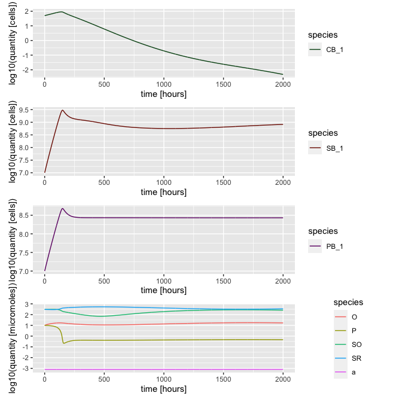

```r
plot_dynamics(anoxic_start_sim_results)
```

## 1 strain oxic start

```r
bush_oxicstart_1strain <- new_starter(values_initial_state = "bush_oxic_fig2cd")
```

```r
oxic_start_sim_results <- run_simulation(
  parameter_values = bush_oxicstart_1strain,
  initial_state = bush_oxicstart_1strain$initial_state
)
```

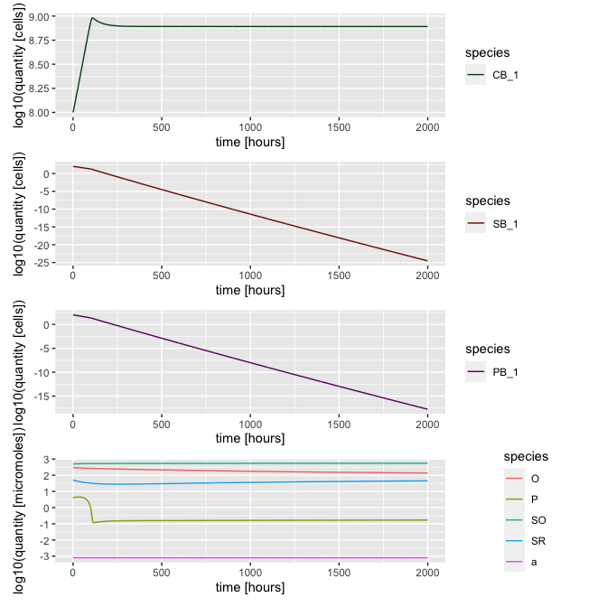

```r
plot_dynamics(oxic_start_sim_results)
```

## Three strains per functional group

Here we simulate a system with three strains per functional group. The system dynamics should not (and do not) differ from the 1 strain version, because the strains within a functional group are (in this case) identical.

```r
multi_strain_paramameter <- new_starter(n_CB = 3,
                                        n_PB = 3,
                                        n_SB = 3)
```

For example, here are the parameters of the three CB strains:

```r
multi_strain_paramameter$CB
```

```
##   strain_name g_max_CB k_CB_P h_SR_CB   y_P_CB Pr_CB m_CB i_CB
## 1        CB_1     0.05    0.2     300 1.67e+08 6e-09 0.02    0
## 2        CB_2     0.05    0.2     300 1.67e+08 6e-09 0.02    0
## 3        CB_3     0.05    0.2     300 1.67e+08 6e-09 0.02    0
```

And the initial state values

```r
multi_strain_paramameter$initial_state
```

```
##  CB_1  CB_2  CB_3  PB_1  PB_2  PB_3  SB_1  SB_2  SB_3    SO    SR     O     P
## 5e+01 5e+01 5e+01 1e+07 1e+07 1e+07 1e+07 1e+07 1e+07 3e+02 3e+02 1e+01 1e+01
## attr(,"class")
## [1] "initial_state" "numeric"
```

So we can see the different strains, we now give them slightly different initial abundances:

```r
multi_strain_paramameter$initial_state["CB_1"] <- 5e3
multi_strain_paramameter$initial_state["CB_2"] <- 1e3
multi_strain_paramameter$initial_state["CB_3"] <- 0
multi_strain_paramameter$initial_state["PB_1"] <- 1e7
multi_strain_paramameter$initial_state["PB_2"] <- 1e6
multi_strain_paramameter$initial_state["PB_3"] <- 1e5
multi_strain_paramameter$initial_state["SB_1"] <- 1e7
multi_strain_paramameter$initial_state["SB_2"] <- 1e6
multi_strain_paramameter$initial_state["SB_3"] <- 1e5
#multi_strain_paramameter$initial_state["SO"] <- 300
#multi_strain_paramameter$initial_state["SR"] <- 300
#multi_strain_paramameter$initial_state["O"] <- 1e1
#multi_strain_paramameter$initial_state["P"] <- 1e1
```

```r
simulation_result3 <- run_simulation(
  parameter_values = multi_strain_paramameter,
  initial_state = multi_strain_paramameter$initial_state
)
```

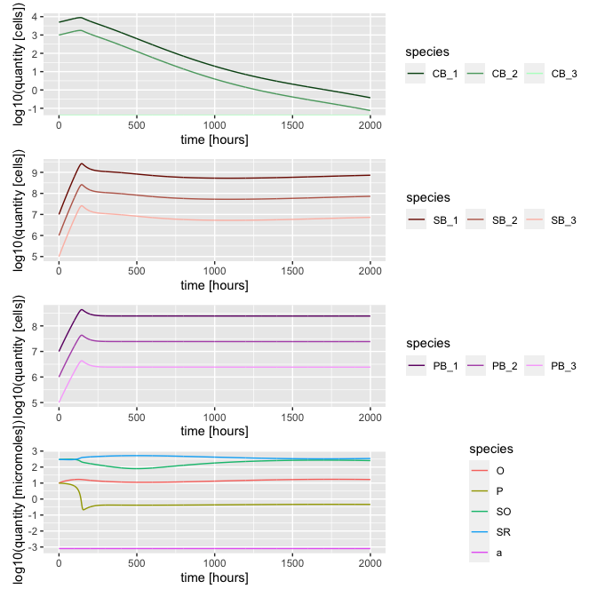

```r
simulation_result3 <- readRDS(file = "data/user_guide/multistrain3.RDS")
plot_dynamics(simulation_result3)
```

# Get steady state(s)

## 1 strain per functional group

Finding the steady state of the system is a common task. The function `ss_by_a_N()` finds the steady state (`ss`) for different values of the $a_0$ (oxygen diffusivity) parameter, and for different initial conditions ($N$).

Note: The function `ss_by_a_N()` can be told to use multiple cores by setting the relevant option, e.g., `options(mc.cores=8)`

We first set the conditions that will apply to all simulations. Note that these are automatically picked up by the functions called by `ss_by_a_N()` and so do not need to be passed.

We will work with a one strain per functional group model, and unless otherwise changed (which we do) starting with oxic favouring initial conditions.

```r
ssfind_minimum_abundances <- rep(0, 3)
names(ssfind_minimum_abundances) <- c("CB", "PB", "SB")
ssfind_simulation_duration <- 50000
ssfind_simulation_sampling_interval <- ssfind_simulation_duration
ssfind_event_interval <- ssfind_simulation_duration
ssfind_parameters <- new_starter(n_CB = 1,
                                 n_PB = 1,
                                 n_SB = 1,
                                 values_initial_state = "bush_ssfig3")
```

Next we need to define the values of $a_0$ and initial conditions that we will get the steady states of. We create quite continuous variation $a_0$. We, however, only need to vary the initial abundance of CB and have it either high or low, in order to find which of the two possible states that can occur do occur.

```r
grid_num_a <- 100 ## number of a_0 values
a_Os <- 10^seq(-6, -2, length=grid_num_a) ## sequence of a_0 values
grid_num_N <- 2 ## number of N values
initial_CBs <- 10^seq(0, 10, length=grid_num_N) ## sequence of N values
initial_PBs <- 1e8 ## not varied
initial_SBs <- 1e8 ## not varied
## next line creates all possible combinations
expt <- expand.grid(N_CB = initial_CBs,
                    N_PB = initial_PBs,
                    N_SB = initial_SBs,
                    a_O = a_Os)
# next line runs the "experiment", calling various functions to do this.
ss_1strain <- ss_by_a_N(expt, ssfind_parameters)
```

And the results (plotting code hidden):

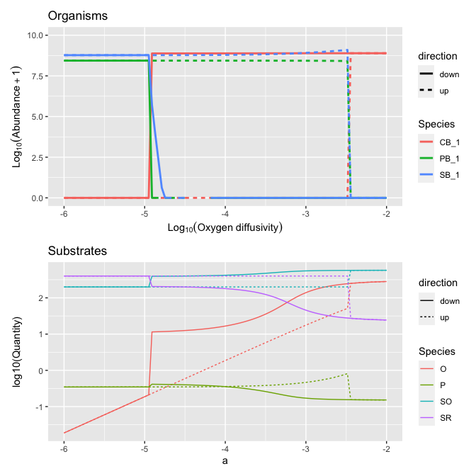

## 3 strains per functional group

And now finding the steady states of a three strain per functional group system, though with identical strains in each group. Hence the steady states should be the same as the one strain version.

Note that the `ss_by_a_N()` function divides the specified starting abundance of a functional group and distributes that equally among the strains of that functional group.

```r
#ssfind_minimum_abundances <- rep(0, 3)
#names(ssfind_minimum_abundances) <- c("CB", "PB", "SB")
#ssfind_simulation_duration <- 50000
#ssfind_simulation_sampling_interval <- ssfind_simulation_duration
#ssfind_event_interval <- ssfind_simulation_duration
ssfind_parameters <- new_starter(n_CB = 3,
                                 n_PB = 3,
                                 n_SB = 3,
                                 values_initial_state = "bush_ssfig3")

#ssfind_init_state
#grid_num_a <- 100
#a_Os <- 10^seq(-6, -2, length=grid_num_a)
#grid_num_N <- 2
#initial_CBs <- 10^seq(0, 10, length=grid_num_N)
#initial_PBs <- 1e5
#initial_SBs <- 1e5
#expt <- expand.grid(N_CB = initial_CBs,
#                    N_PB = initial_PBs,
#                    N_SB = initial_SBs,
#                    a_O = a_Os)

ss_3strain <- ss_by_a_N(expt, ssfind_parameters)
```

And the results (plotting code hidden):

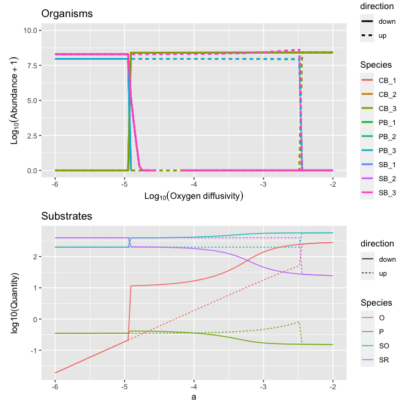

# Get measures of nonlinearity and hysteresis

The `get_stability_measures()` function takes an object of the type returned by the `ss_by_a_N()` function and returns various measures of the stability of each of the state variables.

The measures of non-linearity and hysteresis were used in [Garnier et al (2020) (link to online article)](https://onlinelibrary.wiley.com/doi/abs/10.1002/ece3.6294).

(Warning: Care is required when processing the produced data. Some log transformations with addition of 1 are used; NAs are produced in some cases; and some measures are affected by the number of strains, even when the strains are identical.)

For example:

```r
#ss_object <- ss_1strain

get_stability_measures(ss_1strain)
```

```
## # A tibble: 7 x 7
##   Species hyst_tot hyst_range hyst_min hyst_max   nl_up nl_down
##   <chr>      <dbl>      <dbl>    <dbl>    <dbl>   <dbl>   <dbl>
## 1 CB_1      5.42        2.42     -4.91    -2.48 0.215   0.234
## 2 O         0.507       2.42     -4.91    -2.48 0.0280  0.0173
## 3 P         0.0323      0.485    -2.97    -2.48 0.00296 0.00167
## 4 PB_1      5.14        2.42     -4.91    -2.48 0.204   0.222
## 5 SB_1      5.27        2.42     -4.91    -2.48 0.216   0.227
## 6 SO        0.223       2.42     -4.91    -2.48 0.0110  0.00626
## 7 SR        0.350       2.42     -4.91    -2.48 0.0286  0.0107
```

And with three strains per functional group:

```r
get_stability_measures(ss_3strain)
```

```
## # A tibble: 13 x 7
##    Species hyst_tot hyst_range hyst_min hyst_max   nl_up nl_down
##    <chr>      <dbl>      <dbl>    <dbl>    <dbl>   <dbl>   <dbl>
##  1 CB_1      5.13        2.42     -4.91    -2.48 0.203   0.221
##  2 CB_2      5.13        2.42     -4.91    -2.48 0.203   0.221
##  3 CB_3      5.13        2.42     -4.91    -2.48 0.203   0.221
##  4 O         0.507       2.42     -4.91    -2.48 0.0280  0.0173
##  5 P         0.0323      0.485    -2.97    -2.48 0.00296 0.00167
##  6 PB_1      4.85        2.42     -4.91    -2.48 0.192   0.210
##  7 PB_2      4.85        2.42     -4.91    -2.48 0.192   0.210
##  8 PB_3      4.85        2.42     -4.91    -2.48 0.192   0.210
##  9 SB_1      5.00        2.42     -4.91    -2.48 0.204   0.215
## 10 SB_2      5.00        2.42     -4.91    -2.48 0.204   0.215
## 11 SB_3      5.00        2.42     -4.91    -2.48 0.204   0.215
## 12 SO        0.223       2.42     -4.91    -2.48 0.0110  0.00626
## 13 SR        0.350       2.42     -4.91    -2.48 0.0286  0.0107
```